# Example: Plaque psoriasis HTA report

```r
library(multinma)
options(mc.cores = parallel::detectCores())
```

This vignette describes the analysis of treatments for moderate-to-severe plaque psoriasis from an HTA report (Woolacott et al. 2006), replicating the analysis in NICE Technical Support Document 2 (Dias et al. 2011). The data are available in this package as `hta_psoriasis`:

```r
head(hta_psoriasis)
```

```
#>   studyn   studyc year trtn             trtc sample_size PASI50 PASI75 PASI90
#> 1      1  Elewski 2004    1  Supportive care         193     12      5      1
#> 2      1  Elewski 2004    2 Etanercept 25 mg         196     59     46     21
#> 3      1  Elewski 2004    3 Etanercept 50 mg         194     54     56     40
#> 4      2 Gottlieb 2003    1  Supportive care          55      5      1      0
#> 5      2 Gottlieb 2003    2 Etanercept 25 mg          57     23     11      6
#> 6      3  Lebwohl 2003    1  Supportive care         122     13      5      1
```

Outcomes are ordered multinomial success/failure to achieve 50%, 75%, or 90% reduction in symptoms on the Psoriasis Area and Severity Index (PASI) scale. Some studies report ordered outcomes at all three cutpoints, others only one or two:

```r
dplyr::filter(hta_psoriasis, studyc %in% c("Elewski", "Gordon", "ACD2058g", "Altmeyer"))
```

```
#>   studyn   studyc year trtn             trtc sample_size PASI50 PASI75 PASI90
#> 1      1  Elewski 2004    1  Supportive care         193     12      5      1
#> 2      1  Elewski 2004    2 Etanercept 25 mg         196     59     46     21
#> 3      1  Elewski 2004    3 Etanercept 50 mg         194     54     56     40
#> 4      5   Gordon 2003    1  Supportive care         187     18      8     NA
#> 5      5   Gordon 2003    4       Efalizumab         369    118     98     NA
#> 6      6 ACD2058g 2004    1  Supportive care         170     25     NA     NA
#> 7      6 ACD2058g 2004    4       Efalizumab         162     99     NA     NA
#> 8     10 Altmeyer 1994    1  Supportive care          51     NA      1     NA
#> 9     10 Altmeyer 1994    6         Fumaderm          49     NA     12     NA
```

## Setting up the network

We begin by setting up the network. We have arm-level ordered multinomial count data, so we use the function `set_agd_arm()`. The function `multi()` helps us to specify the ordered outcomes correctly.

```r
pso_net <- set_agd_arm(hta_psoriasis,
                       study = paste(studyc, year),
                       trt = trtc,
                       r = multi(r0 = sample_size - rowSums(cbind(PASI50, PASI75, PASI90), na.rm = TRUE),
                                 PASI50, PASI75, PASI90,
                                 inclusive = FALSE,
                                 type = "ordered"))
pso_net
```

```
#> A network with 16 AgD studies (arm-based).
#>
#> ------------------------------------------------------- AgD studies (arm-based) ----
#>  Study         Treatment arms
#>  ACD2058g 2004 2: Supportive care | Efalizumab
#>  ACD2600g 2004 2: Supportive care | Efalizumab
#>  Altmeyer 1994 2: Supportive care | Fumaderm
#>  Chaudari 2001 2: Supportive care | Infliximab
#>  Elewski 2004  3: Supportive care | Etanercept 25 mg | Etanercept 50 mg
#>  Ellis 1991    3: Supportive care | Ciclosporin | Ciclosporin
#>  Gordon 2003   2: Supportive care | Efalizumab
#>  Gottlieb 2003 2: Supportive care | Etanercept 25 mg
#>  Gottlieb 2004 3: Supportive care | Infliximab | Infliximab
#>  Guenther 1991 2: Supportive care | Ciclosporin
#>  ... plus 6 more studies
#>
#>  Outcome type: ordered (4 categories)
#> ------------------------------------------------------------------------------------
#> Total number of treatments: 8
#> Total number of studies: 16
#> Reference treatment is: Supportive care
#> Network is connected
```

Plot the network structure.

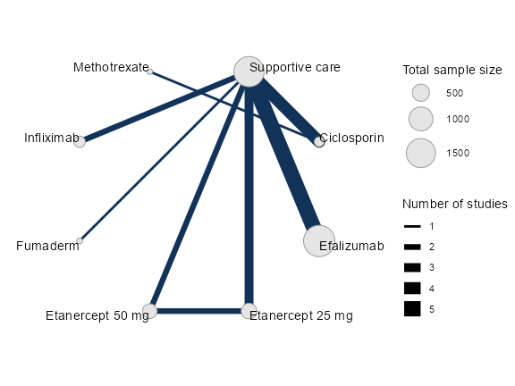

```r
plot(pso_net, weight_edges = TRUE, weight_nodes = TRUE) +
  # Nudge the legend over
  ggplot2::theme(legend.box.spacing = ggplot2::unit(0.75, "in"),
                 plot.margin = ggplot2::margin(0.1, 0, 0.1, 0.75, "in"))
```

## Meta-analysis models

We fit both fixed effect (FE) and random effects (RE) models.

### Fixed effect meta-analysis

First, we fit a fixed effect model using the `nma()` function with `trt_effects = "fixed"`, using a probit link function `link = "probit"`. We use $\mathrm{N}(0, 10^2)$ prior distributions for the treatment effects $d_k$, and $\mathrm{N}(0, 100^2)$ prior distributions for the study-specific intercepts $\mu_j$. We can examine the range of parameter values implied by these prior distributions with the `summary()` method:

```r
summary(normal(scale = 10))
```

```
#> A Normal prior distribution: location = 0, scale = 10.
#> 50% of the prior density lies between -6.74 and 6.74.
#> 95% of the prior density lies between -19.6 and 19.6.
```

```r
summary(normal(scale = 100))
```

```
#> A Normal prior distribution: location = 0, scale = 100.
#> 50% of the prior density lies between -67.45 and 67.45.
#> 95% of the prior density lies between -196 and 196.
```

We also need to specify prior distributions for the latent cutpoints $c_\textrm{PASI75}$ and $c_\textrm{PASI90}$ on the underlying scale - here the PASI standardised mean difference due to the probit link (the cutpoint $c_\textrm{PASI50}=0$). To make these easier to reason about, we actually specify priors on the *differences* between adjacent cutpoints, e.g. $c_\textrm{PASI90} - c_\textrm{PASI75}$ and $c_\textrm{PASI75} - c_\textrm{PASI50}$. These can be given any positive-valued prior distribution, and Stan will automatically impose the necessary ordering constraints behind the scenes. We choose to give these implicit flat priors `flat()`.

The model is fitted using the `nma()` function.

```r
pso_fit_FE <- nma(pso_net,
                  trt_effects = "fixed",
                  link = "probit",
                  prior_intercept = normal(scale = 100),
                  prior_trt = normal(scale = 10),
                  prior_aux = flat())
```

```
#> Note: Setting "Supportive care" as the network reference treatment.
```

Basic parameter summaries are given by the `print()` method:

```r
pso_fit_FE
```

```
#> A fixed effects NMA with a ordered likelihood (probit link).
#> Inference for Stan model: ordered_multinomial.
#> 4 chains, each with iter=2000; warmup=1000; thin=1;
#> post-warmup draws per chain=1000, total post-warmup draws=4000.
#>
#>                         mean se_mean   sd     2.5%      25%      50%      75%    97.5% n_eff Rhat
#> d[Ciclosporin]          1.92    0.01 0.34     1.27     1.69     1.91     2.14     2.61  1542    1
#> d[Efalizumab]           1.19    0.00 0.06     1.07     1.15     1.19     1.23     1.30  2011    1
#> d[Etanercept 25 mg]     1.51    0.00 0.09     1.33     1.45     1.51     1.58     1.70  2125    1
#> d[Etanercept 50 mg]     1.92    0.00 0.10     1.73     1.85     1.92     1.99     2.12  2228    1
#> d[Fumaderm]             1.48    0.01 0.49     0.60     1.13     1.45     1.78     2.55  2766    1
#> d[Infliximab]           2.33    0.01 0.27     1.83     2.15     2.32     2.50     2.89  2717    1
#> d[Methotrexate]         1.61    0.01 0.44     0.78     1.31     1.61     1.91     2.51  1800    1
#> lp__                -3405.26    0.09 3.58 -3413.59 -3407.46 -3404.85 -3402.65 -3399.36  1472    1
#> cc[PASI50]              0.00     NaN 0.00     0.00     0.00     0.00     0.00     0.00   NaN  NaN
#> cc[PASI75]              0.76    0.00 0.03     0.70     0.74     0.76     0.78     0.82  4912    1
#> cc[PASI90]              1.56    0.00 0.05     1.47     1.53     1.56     1.60     1.67  5098    1
#>
#> Samples were drawn using NUTS(diag_e) at Mon Apr 29 16:50:37 2024.
#> For each parameter, n_eff is a crude measure of effective sample size,
#> and Rhat is the potential scale reduction factor on split chains (at
#> convergence, Rhat=1).
```

> **Note:** the treatment effects are the *opposite sign* to those in TSD 2 (Dias et al. 2011). This is because we parameterise the linear predictor as $\mu_j + d_k + c_m$, rather than $\mu_j + d_k - c_m$. The interpretation here thus follows that of a standard binomial probit (or logit) regression; SMDs (or log ORs) greater than zero mean that the treatment increases the probability of an event compared to the comparator (and less than zero mean a reduction in probability). Here higher outcomes are positive, and all of the active treatments are estimated to increase the response (i.e. a greater reduction) on the PASI scale compared to the network reference (supportive care).

By default, summaries of the study-specific intercepts $\mu_j$ are hidden, but could be examined by changing the `pars` argument:

```r
# Not run
print(pso_fit_FE, pars = c("d", "mu", "cc"))
```

The prior and posterior distributions can be compared visually using the `plot_prior_posterior()` function:

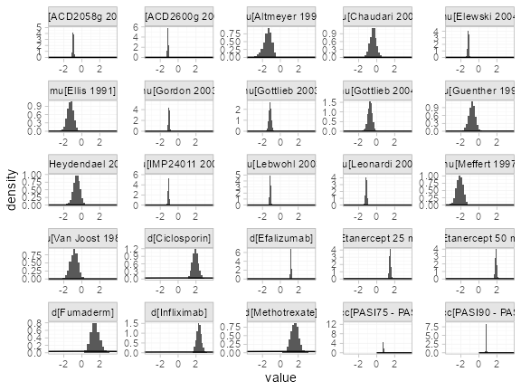

```r
plot_prior_posterior(pso_fit_FE)
```

Focusing specifically on the cutpoints we see that these are highly identified by the data, which is why the implicit flat priors work for these parameters.

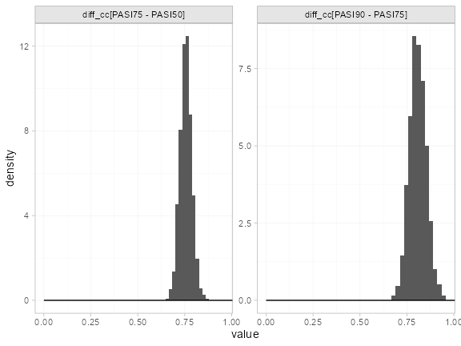

```r
plot_prior_posterior(pso_fit_FE, prior = "aux")
```

### Random effects meta-analysis

We now fit a random effects model using the `nma()` function with `trt_effects = "random"`. Again, we use $\mathrm{N}(0, 10^2)$ prior distributions for the treatment effects $d_k$, $\mathrm{N}(0, 100^2)$ prior distributions for the study-specific intercepts $\mu_j$, implicit flat prior distributions for the latent cutpoints, and we additionally use a $\textrm{half-N}(2.5^2)$ prior for the heterogeneity standard deviation $\tau$. We can examine the range of parameter values implied by these prior distributions with the `summary()` method:

```r
summary(normal(scale = 10))
```

```
#> A Normal prior distribution: location = 0, scale = 10.
#> 50% of the prior density lies between -6.74 and 6.74.
#> 95% of the prior density lies between -19.6 and 19.6.
```

```r
summary(normal(scale = 100))
```

```
#> A Normal prior distribution: location = 0, scale = 100.
#> 50% of the prior density lies between -67.45 and 67.45.
#> 95% of the prior density lies between -196 and 196.
```

```r
summary(half_normal(scale = 2.5))
```

```
#> A half-Normal prior distribution: location = 0, scale = 2.5.
#> 50% of the prior density lies between 0 and 1.69.
#> 95% of the prior density lies between 0 and 4.9.
```

Fitting the RE model

```r
pso_fit_RE <- nma(pso_net,
                  trt_effects = "random",
                  link = "probit",
                  prior_intercept = normal(scale = 100),
                  prior_trt = normal(scale = 10),
                  prior_aux = flat(),
                  prior_het = half_normal(scale = 2.5),
                  adapt_delta = 0.99)
```

```
#> Note: Setting "Supportive care" as the network reference treatment.
```

Basic parameter summaries are given by the `print()` method:

```r
pso_fit_RE
```

```
#> A random effects NMA with a ordered likelihood (probit link).
#> Inference for Stan model: ordered_multinomial.
#> 4 chains, each with iter=5000; warmup=2500; thin=1;
#> post-warmup draws per chain=2500, total post-warmup draws=10000.
#>
#>                         mean se_mean   sd     2.5%      25%      50%      75%    97.5% n_eff Rhat
#> d[Ciclosporin]          2.02    0.01 0.42     1.29     1.73     1.99     2.26     2.93  3254 1.00
#> d[Efalizumab]           1.19    0.00 0.18     0.81     1.10     1.19     1.27     1.56  4674 1.00
#> d[Etanercept 25 mg]     1.53    0.00 0.24     1.04     1.41     1.52     1.65     2.02  5301 1.00
#> d[Etanercept 50 mg]     1.92    0.00 0.27     1.36     1.79     1.92     2.06     2.48  4726 1.00
#> d[Fumaderm]             1.49    0.01 0.60     0.36     1.08     1.46     1.85     2.77  7513 1.00
#> d[Infliximab]           2.31    0.00 0.37     1.58     2.08     2.31     2.54     3.04  7618 1.00
#> d[Methotrexate]         1.71    0.01 0.63     0.60     1.29     1.67     2.07     3.05  4457 1.00
#> lp__                -3410.87    0.19 6.66 -3424.53 -3415.37 -3410.59 -3406.24 -3398.55  1254 1.00
#> tau                     0.30    0.01 0.21     0.02     0.15     0.26     0.41     0.83   872 1.01
#> cc[PASI50]              0.00     NaN 0.00     0.00     0.00     0.00     0.00     0.00   NaN  NaN
#> cc[PASI75]              0.76    0.00 0.03     0.70     0.74     0.76     0.78     0.82 16145 1.00
#> cc[PASI90]              1.56    0.00 0.05     1.46     1.53     1.56     1.60     1.67 20656 1.00
#>
#> Samples were drawn using NUTS(diag_e) at Mon Apr 29 16:51:56 2024.
#> For each parameter, n_eff is a crude measure of effective sample size,
#> and Rhat is the potential scale reduction factor on split chains (at
#> convergence, Rhat=1).
```

By default, summaries of the study-specific intercepts $\mu_j$ and study-specific relative effects $\delta_{jk}$ are hidden, but could be examined by changing the `pars` argument:

```r
# Not run
print(pso_fit_RE, pars = c("d", "cc", "mu", "delta"))
```

The prior and posterior distributions can be compared visually using the `plot_prior_posterior()` function:

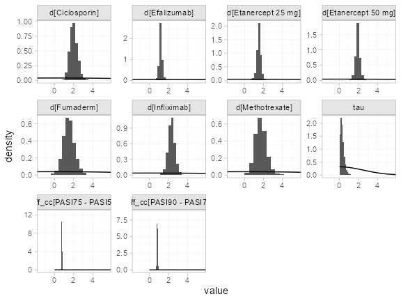

```r
plot_prior_posterior(pso_fit_RE, prior = c("trt", "aux", "het"))
```

### Model comparison

Model fit can be checked using the `dic()` function:

```r
(dic_FE <- dic(pso_fit_FE))
```

```
#> Residual deviance: 75.1 (on 58 data points)
#>                pD: 25.7
#>               DIC: 100.9
```

```r
(dic_RE <- dic(pso_fit_RE))
```

```
#> Residual deviance: 63.3 (on 58 data points)
#>                pD: 33.5
#>               DIC: 96.8
```

The random effects model has a lower DIC and the residual deviance is closer to the number of data points, so is preferred in this case.

We can also examine the residual deviance contributions with the corresponding `plot()` method.

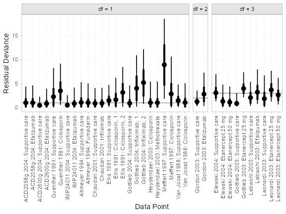

```r
plot(dic_FE)
```

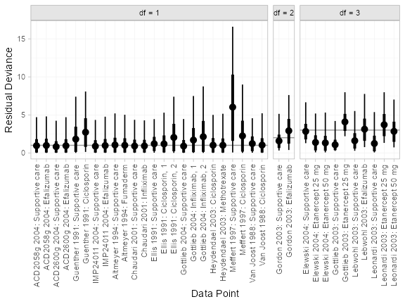

```r
plot(dic_RE)
```

Most data points are fit well, with posterior mean residual deviances close to the degrees of freedom. The Meffert 1997 study has a substantially higher residual deviance contribution, which could be investigated further to see why this study appears to be an outlier.

## Further results

### Predicted probabilities of response

Dias et al. (2011) produce absolute predictions of probability of achieving responses at each PASI cutoff, assuming a Normal distribution for the baseline probit probability of PASI50 response on supportive care with mean $-1.097$ and precision $123$. We can replicate these results using the `predict()` method. The `baseline` argument takes a `distr()` distribution object, with which we specify the corresponding Normal distribution. We set `type = "response"` to produce predicted probabilities (`type = "link"` would produce predicted probit probabilities).

```r
pred_FE <- predict(pso_fit_FE,
                   baseline = distr(qnorm, mean = -1.097, sd = 123^-0.5),
                   type = "response")
pred_FE
```

```
#>                                mean   sd 2.5%  25%  50%  75% 97.5% Bulk_ESS Tail_ESS Rhat
#> pred[Supportive care, PASI50]  0.14 0.02 0.10 0.12 0.14 0.15  0.18     3631     3432    1
#> pred[Supportive care, PASI75]  0.03 0.01 0.02 0.03 0.03 0.04  0.05     3711     3337    1
#> pred[Supportive care, PASI90]  0.00 0.00 0.00 0.00 0.00 0.00  0.01     3807     3857    1
#> pred[Ciclosporin, PASI50]      0.78 0.10 0.57 0.72 0.79 0.85  0.94     1633     2174    1
#> pred[Ciclosporin, PASI75]      0.52 0.13 0.28 0.43 0.52 0.62  0.79     1625     2317    1
#> pred[Ciclosporin, PASI90]      0.24 0.11 0.08 0.16 0.22 0.30  0.49     1642     2010    1
#> pred[Efalizumab, PASI50]       0.54 0.04 0.45 0.51 0.54 0.56  0.62     2935     3506    1
#> pred[Efalizumab, PASI75]       0.25 0.04 0.19 0.23 0.25 0.28  0.33     3030     3880    1
#> pred[Efalizumab, PASI90]       0.07 0.02 0.05 0.06 0.07 0.08  0.11     3140     3464    1
#> pred[Etanercept 25 mg, PASI50] 0.66 0.05 0.56 0.63 0.66 0.69  0.75     2520     3160    1
#> pred[Etanercept 25 mg, PASI75] 0.37 0.05 0.28 0.33 0.37 0.40  0.47     2597     2945    1
#> pred[Etanercept 25 mg, PASI90] 0.13 0.03 0.08 0.11 0.13 0.15  0.19     2697     3643    1
#> pred[Etanercept 50 mg, PASI50] 0.79 0.04 0.71 0.77 0.79 0.82  0.86     2558     3180    1
#> pred[Etanercept 50 mg, PASI75] 0.53 0.05 0.42 0.49 0.53 0.56  0.63     2610     2722    1
#> pred[Etanercept 50 mg, PASI90] 0.23 0.04 0.16 0.20 0.23 0.26  0.32     2659     3182    1
#> pred[Fumaderm, PASI50]         0.63 0.17 0.30 0.51 0.63 0.76  0.93     3000     2201    1
#> pred[Fumaderm, PASI75]         0.37 0.17 0.10 0.23 0.34 0.47  0.77     2976     2264    1
#> pred[Fumaderm, PASI90]         0.15 0.12 0.02 0.06 0.11 0.19  0.46     2980     2254    1
#> pred[Infliximab, PASI50]       0.88 0.05 0.76 0.85 0.89 0.92  0.97     2820     2596    1
#> pred[Infliximab, PASI75]       0.68 0.10 0.48 0.61 0.68 0.75  0.86     2770     2518    1
#> pred[Infliximab, PASI90]       0.38 0.11 0.19 0.30 0.37 0.45  0.61     2797     2499    1
#> pred[Methotrexate, PASI50]     0.68 0.15 0.37 0.58 0.70 0.80  0.92     1858     2106    1
#> pred[Methotrexate, PASI75]     0.41 0.16 0.13 0.29 0.40 0.53  0.75     1845     2027    1
#> pred[Methotrexate, PASI90]     0.17 0.11 0.03 0.09 0.15 0.23  0.45     1855     2113    1
```

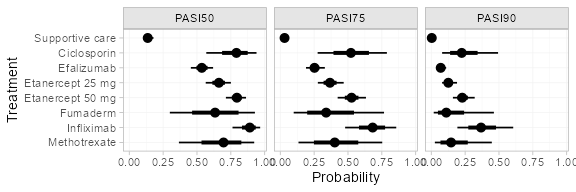

```r
plot(pred_FE)
```

```r
pred_RE <- predict(pso_fit_RE,
                   baseline = distr(qnorm, mean = -1.097, sd = 123^-0.5),
                   type = "response")
pred_RE
```

```
#>                                mean   sd 2.5%  25%  50%  75% 97.5% Bulk_ESS Tail_ESS Rhat
#> pred[Supportive care, PASI50]  0.14 0.02 0.10 0.12 0.14 0.15  0.18     9886     9993    1
#> pred[Supportive care, PASI75]  0.03 0.01 0.02 0.03 0.03 0.04  0.05    10332     9526    1
#> pred[Supportive care, PASI90]  0.00 0.00 0.00 0.00 0.00 0.00  0.01    11235     9542    1
#> pred[Ciclosporin, PASI50]      0.80 0.11 0.57 0.73 0.81 0.88  0.97     3802     3564    1
#> pred[Ciclosporin, PASI75]      0.56 0.15 0.27 0.45 0.55 0.66  0.87     3771     3580    1
#> pred[Ciclosporin, PASI90]      0.28 0.14 0.08 0.17 0.25 0.35  0.62     3879     3629    1
#> pred[Efalizumab, PASI50]       0.54 0.08 0.38 0.49 0.54 0.58  0.69     5601     3346    1
#> pred[Efalizumab, PASI75]       0.26 0.06 0.14 0.22 0.25 0.29  0.40     5684     3423    1
#> pred[Efalizumab, PASI90]       0.07 0.03 0.03 0.06 0.07 0.09  0.15     5852     3938    1
#> pred[Etanercept 25 mg, PASI50] 0.66 0.09 0.47 0.61 0.67 0.72  0.83     6096     4236    1
#> pred[Etanercept 25 mg, PASI75] 0.38 0.09 0.20 0.32 0.37 0.43  0.58     6104     4272    1
#> pred[Etanercept 25 mg, PASI90] 0.14 0.06 0.05 0.10 0.13 0.16  0.27     6186     4399    1
#> pred[Etanercept 50 mg, PASI50] 0.79 0.08 0.60 0.75 0.80 0.84  0.92     5675     3803    1
#> pred[Etanercept 50 mg, PASI75] 0.53 0.11 0.30 0.47 0.53 0.59  0.74     5699     3704    1
#> pred[Etanercept 50 mg, PASI90] 0.24 0.08 0.09 0.19 0.23 0.28  0.43     5759     3824    1
#> pred[Fumaderm, PASI50]         0.63 0.19 0.23 0.49 0.64 0.78  0.95     7867     5674    1
#> pred[Fumaderm, PASI75]         0.37 0.20 0.07 0.22 0.35 0.50  0.82     7842     5826    1
#> pred[Fumaderm, PASI90]         0.16 0.14 0.01 0.06 0.12 0.21  0.55     7852     5891    1
#> pred[Infliximab, PASI50]       0.87 0.08 0.68 0.83 0.89 0.93  0.98     8008     5911    1
#> pred[Infliximab, PASI75]       0.67 0.13 0.39 0.58 0.68 0.76  0.89     7961     5649    1
#> pred[Infliximab, PASI90]       0.37 0.13 0.14 0.28 0.36 0.46  0.66     8030     5646    1
#> pred[Methotrexate, PASI50]     0.70 0.18 0.30 0.58 0.72 0.84  0.98     4997     3897    1
#> pred[Methotrexate, PASI75]     0.45 0.21 0.10 0.29 0.43 0.59  0.89     4991     4113    1
#> pred[Methotrexate, PASI90]     0.21 0.17 0.02 0.09 0.16 0.28  0.66     5065     3963    1
```

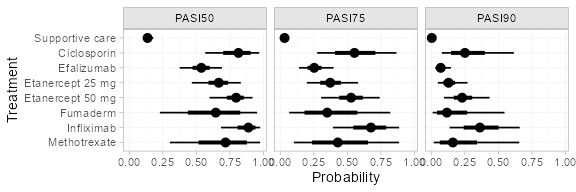

```r
plot(pred_RE)
```

If instead of information on the baseline PASI 50 response probit probability we have PASI 50 event counts, we can use these to construct a Beta distribution for the baseline probability of PASI 50 response. For example, if 56 out of 408 individuals achieved PASI 50 response on supportive care in the target population of interest, the appropriate Beta distribution for the response probability would be $\textrm{Beta}(56, 408-56)$. We can specify this Beta distribution for the baseline response using the `baseline_type = "reponse"` argument (the default is `"link"`, used above for the baseline probit probability).

```r
pred_FE_beta <- predict(pso_fit_FE,
                        baseline = distr(qbeta, 56, 408-56),
                        baseline_type = "response",
                        type = "response")
pred_FE_beta
```

```
#>                                mean   sd 2.5%  25%  50%  75% 97.5% Bulk_ESS Tail_ESS Rhat
#> pred[Supportive care, PASI50]  0.14 0.02 0.10 0.12 0.14 0.15  0.17     3940     4002    1
#> pred[Supportive care, PASI75]  0.03 0.01 0.02 0.03 0.03 0.04  0.05     4005     4022    1
#> pred[Supportive care, PASI90]  0.00 0.00 0.00 0.00 0.00 0.00  0.01     4272     4064    1
#> pred[Ciclosporin, PASI50]      0.78 0.10 0.57 0.72 0.79 0.85  0.93     1611     2198    1
#> pred[Ciclosporin, PASI75]      0.52 0.13 0.28 0.43 0.52 0.61  0.78     1605     2222    1
#> pred[Ciclosporin, PASI90]      0.24 0.11 0.08 0.16 0.23 0.30  0.49     1621     2346    1
#> pred[Efalizumab, PASI50]       0.54 0.04 0.46 0.51 0.54 0.56  0.61     3015     3689    1
#> pred[Efalizumab, PASI75]       0.25 0.03 0.19 0.23 0.25 0.28  0.32     3175     3752    1
#> pred[Efalizumab, PASI90]       0.07 0.01 0.05 0.06 0.07 0.08  0.10     3247     3443    1
#> pred[Etanercept 25 mg, PASI50] 0.66 0.05 0.57 0.63 0.66 0.69  0.75     2588     3092    1
#> pred[Etanercept 25 mg, PASI75] 0.37 0.05 0.28 0.34 0.37 0.40  0.47     2672     3101    1
#> pred[Etanercept 25 mg, PASI90] 0.13 0.03 0.08 0.11 0.13 0.14  0.19     2949     3301    1
#> pred[Etanercept 50 mg, PASI50] 0.79 0.04 0.72 0.77 0.79 0.82  0.86     2577     3029    1
#> pred[Etanercept 50 mg, PASI75] 0.53 0.05 0.43 0.49 0.53 0.56  0.63     2633     3000    1
#> pred[Etanercept 50 mg, PASI90] 0.23 0.04 0.16 0.20 0.23 0.26  0.31     2807     3081    1
#> pred[Fumaderm, PASI50]         0.63 0.17 0.30 0.51 0.63 0.75  0.93     3063     2212    1
#> pred[Fumaderm, PASI75]         0.37 0.17 0.10 0.24 0.34 0.47  0.76     3039     2251    1
#> pred[Fumaderm, PASI90]         0.15 0.12 0.02 0.06 0.11 0.19  0.46     3049     2195    1
#> pred[Infliximab, PASI50]       0.88 0.05 0.76 0.85 0.89 0.92  0.97     2726     2652    1
#> pred[Infliximab, PASI75]       0.68 0.10 0.48 0.61 0.68 0.75  0.86     2717     2641    1
#> pred[Infliximab, PASI90]       0.38 0.11 0.19 0.30 0.37 0.45  0.61     2757     2551    1
#> pred[Methotrexate, PASI50]     0.68 0.15 0.37 0.58 0.70 0.79  0.92     1854     2223    1
#> pred[Methotrexate, PASI75]     0.41 0.16 0.14 0.29 0.41 0.52  0.75     1848     2526    1
#> pred[Methotrexate, PASI90]     0.17 0.11 0.03 0.09 0.15 0.23  0.44     1857     2347    1
```

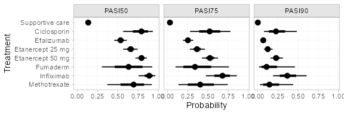

```r
plot(pred_FE_beta)
```

```r
pred_RE_beta <- predict(pso_fit_RE,
                        baseline = distr(qbeta, 56, 408-56),
                        baseline_type = "response",
                        type = "response")
pred_RE_beta
```

```
#>                                mean   sd 2.5%  25%  50%  75% 97.5% Bulk_ESS Tail_ESS Rhat
#> pred[Supportive care, PASI50]  0.14 0.02 0.11 0.13 0.14 0.15  0.17     9843     9606    1
#> pred[Supportive care, PASI75]  0.03 0.01 0.02 0.03 0.03 0.04  0.05    10394     9888    1
#> pred[Supportive care, PASI90]  0.00 0.00 0.00 0.00 0.00 0.00  0.01    11660     9942    1
#> pred[Ciclosporin, PASI50]      0.80 0.11 0.57 0.74 0.81 0.88  0.97     3811     3800    1
#> pred[Ciclosporin, PASI75]      0.56 0.15 0.28 0.45 0.55 0.66  0.86     3780     3772    1
#> pred[Ciclosporin, PASI90]      0.27 0.14 0.08 0.17 0.25 0.35  0.61     3865     3928    1
#> pred[Efalizumab, PASI50]       0.54 0.07 0.38 0.49 0.54 0.58  0.69     5503     3485    1
#> pred[Efalizumab, PASI75]       0.26 0.06 0.14 0.22 0.25 0.29  0.40     5590     3413    1
#> pred[Efalizumab, PASI90]       0.07 0.03 0.03 0.06 0.07 0.09  0.14     5783     3664    1
#> pred[Etanercept 25 mg, PASI50] 0.66 0.09 0.47 0.62 0.67 0.71  0.82     6002     4220    1
#> pred[Etanercept 25 mg, PASI75] 0.38 0.09 0.20 0.32 0.37 0.42  0.57     6006     4277    1
#> pred[Etanercept 25 mg, PASI90] 0.14 0.06 0.05 0.10 0.13 0.16  0.27     6086     4211    1
#> pred[Etanercept 50 mg, PASI50] 0.79 0.08 0.60 0.75 0.80 0.83  0.92     5596     3660    1
#> pred[Etanercept 50 mg, PASI75] 0.53 0.10 0.30 0.47 0.53 0.59  0.74     5596     3685    1
#> pred[Etanercept 50 mg, PASI90] 0.24 0.08 0.09 0.19 0.23 0.28  0.44     5650     3730    1
#> pred[Fumaderm, PASI50]         0.63 0.19 0.23 0.49 0.64 0.78  0.95     7864     5868    1
#> pred[Fumaderm, PASI75]         0.37 0.20 0.07 0.22 0.35 0.50  0.82     7846     5695    1
#> pred[Fumaderm, PASI90]         0.16 0.14 0.01 0.06 0.12 0.21  0.55     7853     5914    1
#> pred[Infliximab, PASI50]       0.87 0.08 0.68 0.83 0.89 0.93  0.98     8002     5900    1
#> pred[Infliximab, PASI75]       0.67 0.13 0.39 0.58 0.68 0.76  0.89     7951     5679    1
#> pred[Infliximab, PASI90]       0.37 0.13 0.14 0.28 0.36 0.46  0.66     8017     5752    1
#> pred[Methotrexate, PASI50]     0.70 0.18 0.31 0.58 0.72 0.83  0.97     4900     4110    1
#> pred[Methotrexate, PASI75]     0.45 0.21 0.10 0.29 0.43 0.59  0.88     4893     4206    1
#> pred[Methotrexate, PASI90]     0.21 0.17 0.02 0.09 0.16 0.28  0.66     4968     3951    1
```

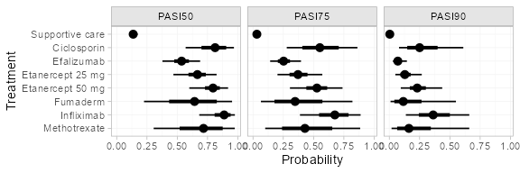

```r
plot(pred_RE_beta)
```

(Notice that these results are equivalent to those calculated above using the Normal distribution for the baseline probit probability, since these event counts correspond to the same probit probability.)

We can modify the plots using standard `ggplot2` functions. For example, to plot the cutpoints together with a colour coding (instead of split into facets):

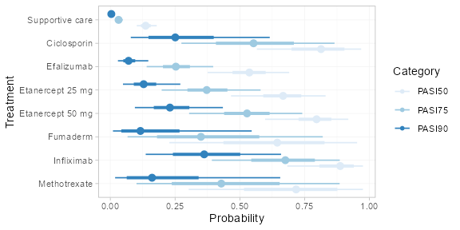

```r
library(ggplot2)
plot(pred_RE, position = position_dodge(width = 0.75)) +
  facet_null() +
  aes(colour = Category) +
  scale_colour_brewer(palette = "Blues")
```

If the `baseline` argument is omitted, predicted probabilities will be produced for every study in the network based on their estimated baseline probit probability $\mu_j$.

### Ranks and rank probabilities

Treatment rankings, rank probabilities, and cumulative rank probabilities can also be produced. We set `lower_better = FALSE` since higher outcome categories are better (the outcomes are positive).

```r
(pso_ranks <- posterior_ranks(pso_fit_RE, lower_better = FALSE))
```

```
#>                        mean   sd 2.5% 25% 50% 75% 97.5% Bulk_ESS Tail_ESS Rhat
#> rank[Supportive care]  7.99 0.10    8   8   8   8     8     5581       NA    1
#> rank[Ciclosporin]      2.78 1.28    1   2   3   4     6     6715     7043    1
#> rank[Efalizumab]       6.35 0.80    4   6   7   7     7     5575     5995    1
#> rank[Etanercept 25 mg] 4.91 1.06    3   4   5   6     7     6994     5325    1
#> rank[Etanercept 50 mg] 3.03 1.22    1   2   3   4     5     5053     4375    1
#> rank[Fumaderm]         4.89 1.94    1   3   5   7     7     7575     6172    1
#> rank[Infliximab]       1.79 1.17    1   1   1   2     5     4072     4882    1
#> rank[Methotrexate]     4.25 1.88    1   3   4   6     7     6156     5513    1
```

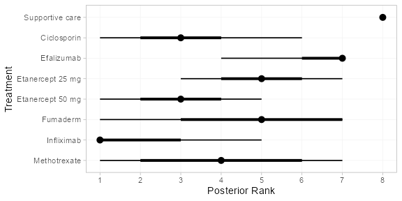

```r
plot(pso_ranks)
```

```r
(pso_rankprobs <- posterior_rank_probs(pso_fit_RE, lower_better = FALSE))
```

```
#>                     p_rank[1] p_rank[2] p_rank[3] p_rank[4] p_rank[5] p_rank[6] p_rank[7] p_rank[8]
#> d[Supportive care]       0.00      0.00      0.00      0.00      0.00      0.00      0.01      0.99
#> d[Ciclosporin]           0.16      0.29      0.28      0.17      0.08      0.02      0.00      0.00
#> d[Efalizumab]            0.00      0.00      0.00      0.02      0.10      0.36      0.51      0.00
#> d[Etanercept 25 mg]      0.00      0.01      0.09      0.21      0.39      0.26      0.04      0.00
#> d[Etanercept 50 mg]      0.08      0.31      0.26      0.24      0.09      0.02      0.01      0.00
#> d[Fumaderm]              0.07      0.09      0.10      0.12      0.15      0.19      0.27      0.01
#> d[Infliximab]            0.59      0.19      0.12      0.06      0.03      0.01      0.00      0.00
#> d[Methotrexate]          0.09      0.12      0.15      0.17      0.17      0.14      0.15      0.00
```

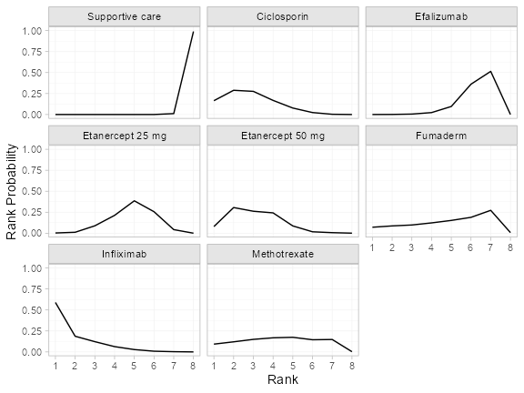

```r
plot(pso_rankprobs)
```

```r
(pso_cumrankprobs <- posterior_rank_probs(pso_fit_RE, lower_better = FALSE, cumulative = TRUE))
```

```
#>                     p_rank[1] p_rank[2] p_rank[3] p_rank[4] p_rank[5] p_rank[6] p_rank[7] p_rank[8]
#> d[Supportive care]       0.00      0.00      0.00      0.00      0.00      0.00      0.01         1
#> d[Ciclosporin]           0.16      0.45      0.73      0.90      0.97      1.00      1.00         1
#> d[Efalizumab]            0.00      0.00      0.01      0.03      0.12      0.49      1.00         1
#> d[Etanercept 25 mg]      0.00      0.01      0.10      0.32      0.70      0.96      1.00         1
#> d[Etanercept 50 mg]      0.08      0.38      0.65      0.89      0.98      0.99      1.00         1
#> d[Fumaderm]              0.07      0.16      0.26      0.38      0.53      0.72      0.99         1
#> d[Infliximab]            0.59      0.78      0.90      0.96      0.99      1.00      1.00         1
#> d[Methotrexate]          0.09      0.21      0.36      0.53      0.70      0.85      1.00         1
```

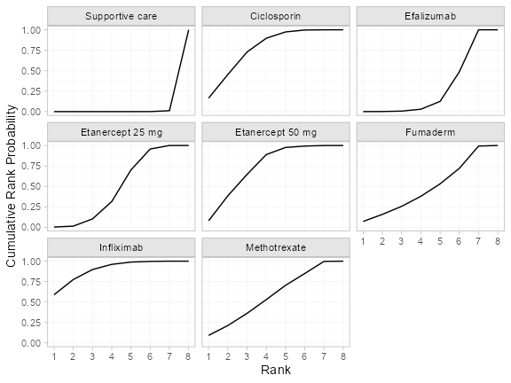

```r
plot(pso_cumrankprobs)
```

## References

Dias, S., N. J. Welton, A. J. Sutton, and A. E. Ades. 2011. “NICE DSU Technical Support Document 2: A Generalised Linear Modelling Framework for Pair-Wise and Network Meta-Analysis of Randomised Controlled Trials.” National Institute for Health and Care Excellence. https://www.sheffield.ac.uk/nice-dsu.

Woolacott, N., N. Hawkins, A. Mason, A. Kainth, Z. Khadjesari, Y. Bravo Vergel, K. Misso, et al. 2006. “Etanercept and Efalizumab for the Treatment of Psoriasis: A Systematic Review.” *Health Technology Assessment* 10 (46). https://doi.org/10.3310/hta10460.